# MedMath2017

ryamada

2017年1月10日

# 1 Rに慣れよう

## 1.1 インストールと起動と終了

Windows : https://oku.edu.mie-u.ac.jp/~okumura/stat/R-win.html

Mac : http://aoki2.si.gunma-u.ac.jp/R/begin.html

## 1.2 付値

計算

```r
3 + 5
```

```
## [1] 8
```

```r
3 * 5
```

```
## [1] 15
```

```r
3 - 5
```

```
## [1] -2
```

```r
3 / 5
```

```
## [1] 0.6
```

```r
3 ^ 5
```

```
## [1] 243
```

変数に値を入れる

```r
x1 <- 3
x2 <- 5
```

入った値を確かめてみる

```r
x1
```

```
## [1] 3
```

```r
x2
```

```
## [1] 5
```

変数を使って計算してみる

```r
x1 + x2
```

```
## [1] 8
```

```r
x1 - x2
```

```
## [1] -2
```

```r
x1 * x2
```

```
## [1] 15
```

```r
x1 / x2
```

```
## [1] 0.6
```

```r
x1 ^ x2
```

```
## [1] 243
```

## 1.3 プロット

$$y = a\sin{x} + b$$

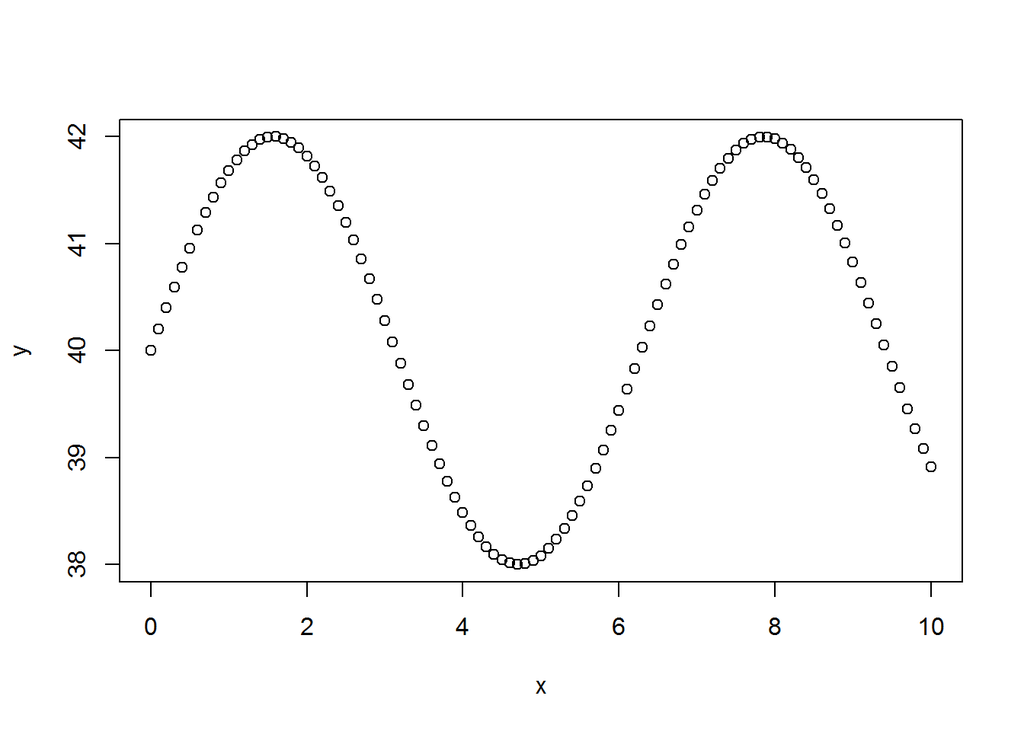

```r
a <- 2
b <- 40
x <- seq(from=0,to=10,by=0.1)
y <- a * sin(x) + b
plot(x,y)
```

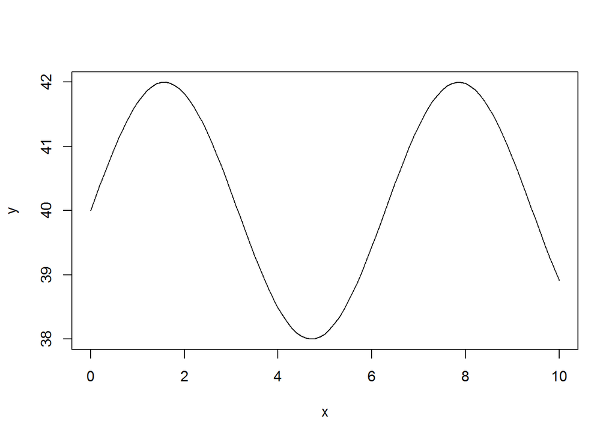

```r
plot(x,y,type="l")
```

### 練習問題１

```r
print(pi)
```

```
## [1] 3.141593
```

## 1.4 格子

等間隔点を組み合わせることで格子状の点座標が作れる。

```r
x <- seq(from = -3, to= 3 , by = 0.1)
y <- seq(from = -3, to = 3, by = 0.1)
# xとyとを組み合わせることで格子点のセットを作る
xy <- expand.grid(x,y)
head(xy)
```

```
##   Var1 Var2
## 1 -3.0   -3
## 2 -2.9   -3
## 3 -2.8   -3
## 4 -2.7   -3
## 5 -2.6   -3
## 6 -2.5   -3
```

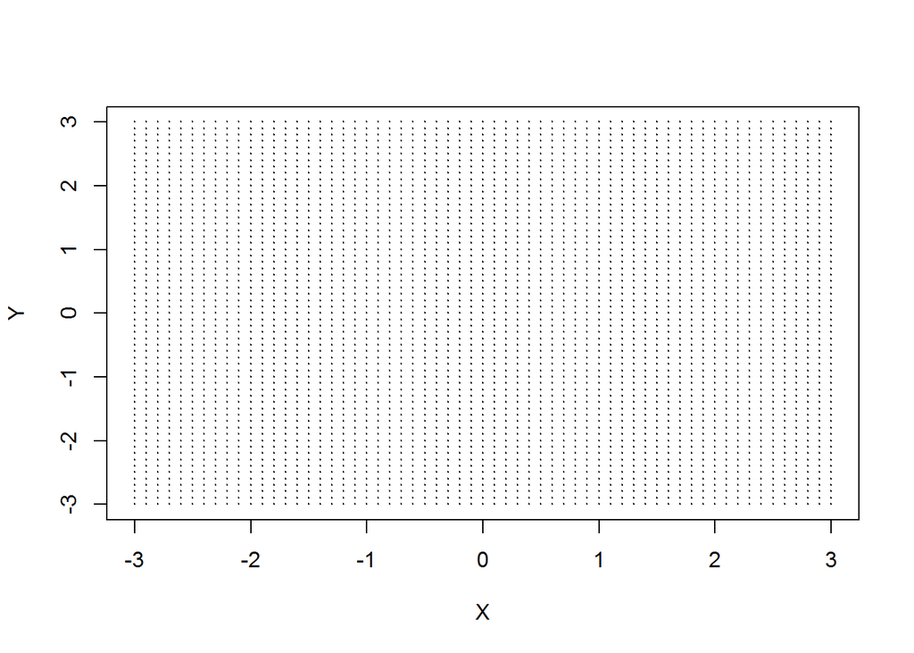

```r
X <- xy[,1]
Y <- xy[,2]
plot(X,Y,pch=20,cex=0.1)
```

xy平面上の点に
$$z = x^2+y^2$$
なる値を与え、その曲面を描く。

```r
Z <- X^2+Y^2
plot3d(X,Y,Z)
```

[interactive chart not shown]

### 1.4.1 練習問題２

2-1
$$z = e^{-(x^2+y^2)}sin(x)*cos(y)$$
なる曲面を描け。

```
##   Var1 Var2
## 1 -3.0   -3
## 2 -2.9   -3
## 3 -2.8   -3
## 4 -2.7   -3
## 5 -2.6   -3
## 6 -2.5   -3
```

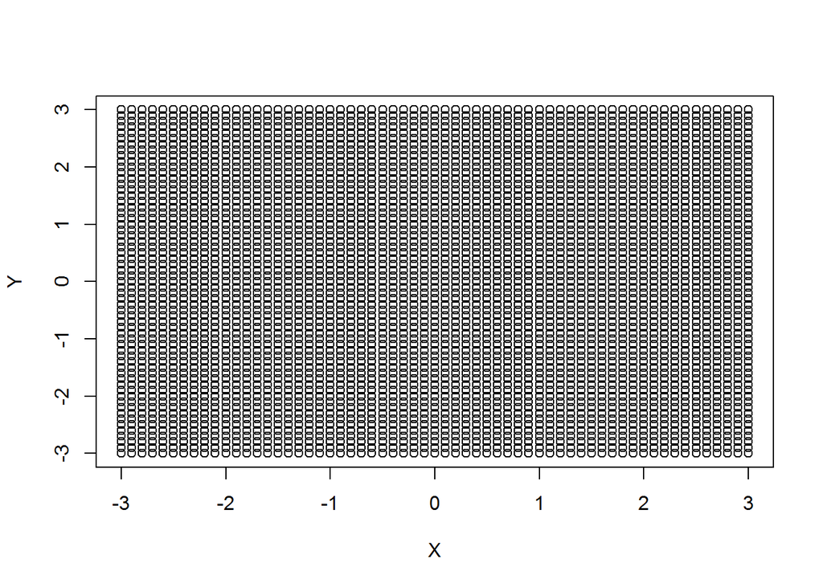

## 1.5 関数を作る

$$z = x^2+y^2$$

は、xとyの値を与えるとそれに応じたzという値を返す「関数」。

コンピュータ言語でも、何かを与えて、それに応じて何かを返すものを関数と呼ぶ。

上式と同じ働きをする関数を作ってみる。

```r
my.f1 <- function(x,y){
  z <- x^2+y^2
  return(z)
}

Z <- my.f1(X,Y)
plot3d(X,Y,Z)
```

[interactive chart not shown]

与えるものを「引数」、返ってくるものを「返り値（かえりち）」と呼ぶ。

### 1.5.1 格子を返す関数を作る

格子を作成するにあたり

```r
x <- seq(from = -3, to= 3 , by = 0.1)
y <- seq(from = -3, to = 3, by = 0.1)
# xとyとを組み合わせることで格子点のセットを作る
xy <- expand.grid(x,y)
```

のようにした。 このように、from = a, to = b, by = kでxとyとをつくり、それを組み合わせた格子を返す関数は以下のように作れる。

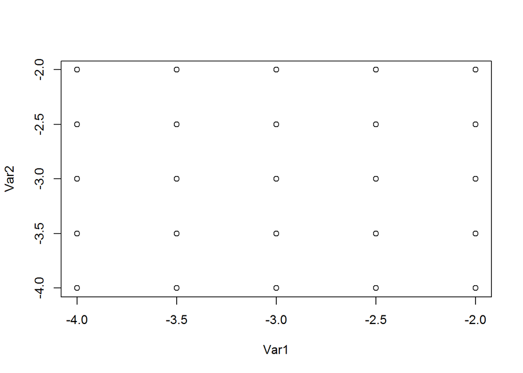

```r
my.f2 <- function(a,b,k){
  x <- seq(from = a, to = b, by =k)
  y <- x
  xy <- expand.grid(x,y)
  return(xy)
}
A <- -4
B <- -2
K <- 0.5
gr <- my.f2(a=A,b=B,k=K)
plot(gr)
```

### 1.5.2 練習問題３

3-1 ２次元平面の原点を中心とする半径rの円の円周上に等間隔に配意されたn個の点の座標を返す関数を作れ。ただし、等間隔点の発生には、等間隔角度を0から$2/pi$までつくり、それに対応する$\cos,\sin$を使って、$x,y$に対応する数値の列を作ればよい、数値列x,yを返すには、

```r
my.f3_1 <- function(r,n){
  # x <- hoge
  # y <- hoge
  return(cbind(x,y)) #このようにすれば２列の行列で返る
  # return(list(X=x,Y=y)) # このようにすれば、X,Yという２つのベクトルが返る
}
```

3-2 上で作成した関数( my.f3_1() )を呼び出して使う関数は次のようにして作れる。 次の関数my.f3_1_plot()は作成した座標をプロットする関数である。

```r
my.f3_1 <- function(r,n){
  # hogehoge
}

my.f3_1_plot <- function(r,n){
  tmp <- my.f3_1(r,n)
  plot(tmp)
}
```

円周上に等間隔に配置した点(x,y)に$z = k \times sin(x\times y)$を与え、(x,y,z)をplot3d()関数を持ちいて３次元プロットする関数を作れ。

# 2 フィボナッチ数列と生物学的現象

## 2.1 数列

$$x_1 = a \\
x_{n+1} = b * x_n$$

このような数列の値を計算する関数を作る。 $x_1$から$x_{n}$までの数列を計算して、一括して返す関数にする。

```r
my.seq.1 <- function(a,b,n){
  ret <- rep(0,n)
  ret[1] <- a
  if(n > 1){
    for(i in 2:n){
      ret[i] <- b * ret[i-1]
    }
  }
  return(ret)
}

sq <- my.seq.1(1,2,10)
sq
```

```
##  [1]   1   2   4   8  16  32  64 128 256 512
```

## 2.2 フィボナッチ数

$$x_1 = 0\\
x_2 = 1\\
x_{n} = x_{n-1}+x_{n-2}$$

```r
n <- 10
x <- rep(0,n)
x[1] <- 0
x[2] <- 1
for(i in 3:n){
  x[i] <- x[i-1]+x[i-2]
}
x
```

```
##  [1]  0  1  1  2  3  5  8 13 21 34
```

### 2.2.1 練習問題４

4-1 フィボナッチ数列を計算する関数を作れ。

```
##  [1]  0  1  1  2  3  5  8 13 21 34
```

## 2.3 らせん

等角度の変化。 半径が一定速度で増加。